# multimediate

## Multiple mediation analysis

```r
library(multimediate)
```

This function is based on the work presented in Jerolon et al 2020 and the R package mediation presented in Tingley et al 2014. Models supported by our R function are shown in the following table.

| Models supported by multimediate. |  |  |  |  |  |
| --- | --- | --- | --- | --- | --- |
|  | Outcome |  |  |  |  |
| Mediators | Linear | Binary | Ordered categorical | Non-ordered categorical |  |
| Linear | Ok | Ok | Ok | Not yet |  |
| Binary (Probit) | Ok | Ok | Ok | Not yet |  |
| Ordered categorical | Ok | Ok | Ok | Not yet |  |
| Non-ordered categorical | Not yet | Not yet | Not yet | Not yet |  |

## Example 1

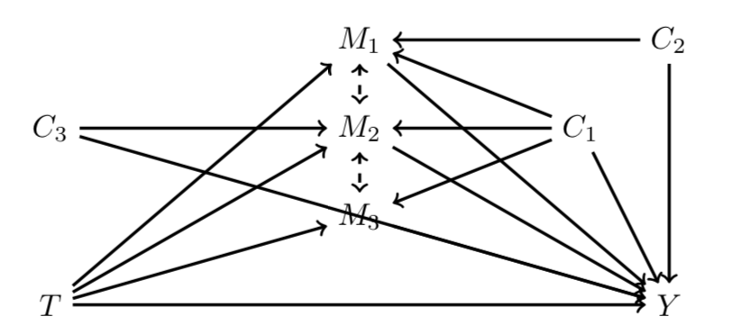

We will do a mediation analysis with the following model.

- Binary treatment : $T$
- Linear Outcome : $Y$
- Linear mediators : $M_1,M_2,M_3$
- Binary covariables : $C_1,C_2,C_3$

In this first example the covariable $C_1$ is affecting all three mediators and the outcome $Y$; the covariable $C_2$ is affecting $M_1$ and the outcome $Y$; and the covariable $C_3$ is affecting $M_2$ and the outcome $Y$ as described in the diagramm.

```r
data(data1)
data1$Treatment=as.factor(data1$Treatment)
data1$C1=as.factor(data1$C1)
data1$C2=as.factor(data1$C2)
data1$C3=as.factor(data1$C3)
data1$M1=as.numeric(data1$M1)
data1$M2=as.numeric(data1$M2)
data1$M3=as.numeric(data1$M3)
data1$Outcome=as.numeric(data1$Outcome)
summary(data1)
```

```
#>  Treatment C1      C2      C3            M1               M2
#>  0:480     0:501   0:417   0:596   Min.   :-1.410   Min.   :-0.8455
#>  1:520     1:499   1:583   1:404   1st Qu.: 2.850   1st Qu.: 4.7567
#>                                    Median : 5.809   Median : 7.2685
#>                                    Mean   : 5.431   Mean   : 7.2333
#>                                    3rd Qu.: 7.921   3rd Qu.: 9.7710
#>                                    Max.   :12.054   Max.   :15.6520
#>        M3             Outcome
#>  Min.   :-0.8298   Min.   : 12.88
#>  1st Qu.: 3.5296   1st Qu.:100.61
#>  Median : 6.8410   Median :145.90
#>  Mean   : 6.6268   Mean   :145.54
#>  3rd Qu.: 9.7148   3rd Qu.:190.45
#>  Max.   :13.5039   Max.   :295.79
```

The regression models are then as follows.

```r
M1reg=lm(M1~ Treatment + C1 + C2, data=data1)
M2reg=lm(M2~ Treatment + C1 + C3, data=data1)
M3reg=lm(M3~ Treatment + C1     , data=data1)

Yreg=lm(Outcome~ Treatment + M1 + M2 + M3 + C1 + C2 + C3, data=data1)
```

Once the regressions are done, we can then proceed to the multiple mediation analysis using the multimediate function. Then display the results with the summary function.

```r
med.analysis=multimediate(lmodel.m=list(M1reg,M2reg,M3reg),correlated=TRUE,model.y=Yreg,
                        treat="Treatment",treat.value=1,control.value=0,J=1000,conf.level=0.95)
```

| True values of causal effects in data 1. |  |  |  |  |  |
| --- | --- | --- | --- | --- | --- |
| Total Effect | Direct Effect | Joint Indirect Effect | Indirect Effect by M1 | Indirect Effect by M2 | Indirect Effect by M3 |
| 92 | 10 | 82 | 10 | 18 | 54 |

```r
summary(med.analysis,opt="avg")
```

```
#>               . Estimation  IC.inf  IC.sup P.val
#> 1    ACME.joint    81.5494 79.8501 83.0861     0
#> 2      PM.joint     0.8859  0.8781  0.8942     0
#> 3       ACME.M1    10.3988  9.6326 11.1910     0
#> 4         PM.M1     0.1130  0.1049  0.1218     0
#> 5       ACME.M2    17.5109 16.6270 18.3698     0
#> 6         PM.M2     0.1902  0.1804  0.2003     0
#> 7       ACME.M3    53.6397 52.3675 54.9432     0
#> 8         PM.M3     0.5828  0.5658  0.5995     0
#> 9           ADE    10.5010  9.7397 11.2122     0
#> 10 Total Effect    92.0504 90.5099 93.5028     0
```

```r
#plot(med.analysis)
```

## Example 2

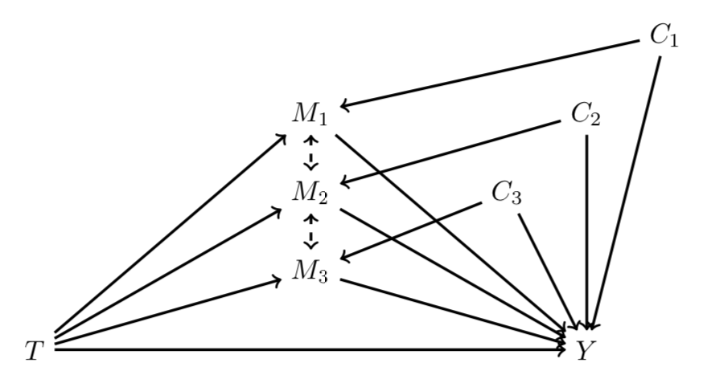

- Binary treatment : $T$
- Binary Outcome : $Y$
- Linear mediators : $M_1,M_2,M_3$
- Binary covariables : $C_1,C_2,C_3$

```r
data(data2)
data2$Treatment=as.factor(data2$Treatment)
data2$C1=as.factor(data2$C1)
data2$C2=as.factor(data2$C2)
data2$C3=as.factor(data2$C3)
data2$M1=as.numeric(data2$M1)
data2$M2=as.numeric(data2$M2)
data2$M3=as.numeric(data2$M3)
data2$Outcome=as.factor(data2$Outcome)
summary(data2)
```

```
#>  Treatment C1      C2      C3            M1                M2
#>  0:514     0:500   0:430   0:610   Min.   :-2.7798   Min.   :-2.19561
#>  1:486     1:500   1:570   1:390   1st Qu.:-0.1127   1st Qu.:-0.04618
#>                                    Median : 0.5923   Median : 0.61047
#>                                    Mean   : 0.5699   Mean   : 0.60425
#>                                    3rd Qu.: 1.2644   3rd Qu.: 1.23342
#>                                    Max.   : 3.8948   Max.   : 3.75137
#>        M3           Outcome
#>  Min.   :-3.3517   FALSE:757
#>  1st Qu.:-0.2396   TRUE :243
#>  Median : 0.4367
#>  Mean   : 0.4572
#>  3rd Qu.: 1.1357
#>  Max.   : 4.0804
```

```r
M1reg=lm(M1~ Treatment + C1, data=data2)
M2reg=lm(M2~ Treatment + C2, data=data2)
M3reg=lm(M3~ Treatment + C3, data=data2)

Yreg=glm(Outcome~ Treatment + M1 + M2 + M3 + C1 + C2 + C3, data=data2, family = binomial("logit"))
```

```r
med.analysis=multimediate(lmodel.m=list(M1reg,M2reg,M3reg),correlated=TRUE,model.y=Yreg,
                        treat="Treatment",treat.value=1,control.value=0,J=1000,conf.level=0.95)
```

| True values of causal effects in data 2 on log OR scale. |  |  |  |  |  |
| --- | --- | --- | --- | --- | --- |
| Total Effect | Direct Effect | Joint Indirect Effect | Indirect Effect by M1 | Indirect Effect by M2 | Indirect Effect by M3 |
| 1.311 | 0.71 | 0.601 | 0.195 | 0.19 | 0.216 |

```r
 summary(med.analysis,opt="avg",logit="all")
```

[output not shown]

```r
# summary(med.analysis,opt="avg",logit="effects")
# plot(med.analysis)


# summary(med.analysis,opt="avg",logit="OR")
#plot(med.analysis,logit = "OR")

#summary(med.analysis,opt="avg",logit="logOR")
#plot(med.analysis,logit = "logOR")
```

## Example 3

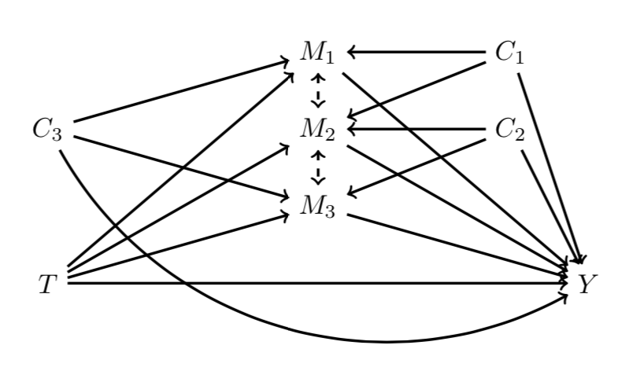

- Binary treatment $T$
- Polytomic Outcome $Y$
- Linear mediators $M_1,M_2,M_3$
- Binary covariables $C_1,C_2,C_3$

```r
data(data3)
data3$Treatment=as.factor(data3$Treatment)
data3$C1=as.factor(data3$C1)
data3$C2=as.factor(data3$C2)
data3$C3=as.factor(data3$C3)
data3$M1=as.numeric(data3$M1)
data3$M2=as.numeric(data3$M2)
data3$M3=as.numeric(data3$M3)
data3$Outcome=as.factor(data3$Outcome)

summary(data3)
```

```
#>  Treatment C1      C2      C3            M1               M2
#>  0:487     0:487   0:399   0:590   Min.   :-1.005   Min.   :-0.3562
#>  1:513     1:513   1:601   1:410   1st Qu.: 5.971   1st Qu.: 7.4968
#>                                    Median : 8.068   Median :12.3671
#>                                    Mean   : 8.640   Mean   :11.2222
#>                                    3rd Qu.:11.451   3rd Qu.:14.2538
#>                                    Max.   :18.107   Max.   :21.2199
#>        M3          Outcome
#>  Min.   :-0.7423   0:516
#>  1st Qu.: 5.5540   1: 64
#>  Median : 9.6019   2:102
#>  Mean   : 9.5298   3:318
#>  3rd Qu.:13.3874
#>  Max.   :19.1836
```

```r
M1reg=lm(M1~ Treatment + C1 + C3, data=data3)
M2reg=lm(M2~ Treatment + C1 + C2, data=data3)
M3reg=lm(M3~ Treatment + C2 + C3, data=data3)

library(MASS)
Yreg=polr(Outcome ~ Treatment + M1 + M2 + M3 + C1 + C2 + C3 , data = data3, method = "probit")
med.analysis=multimediate(lmodel.m=list(M1reg,M2reg,M3reg),correlated=TRUE,model.y=Yreg,
                        treat="Treatment",treat.value=1,control.value=0,J=100,conf.level=0.95)

summary(med.analysis,opt="avg")
```

[output not shown]

```r
summary(med.analysis,opt="avg")
```

```
#>               . Estimation IC.inf IC.sup P.val
#> 1    ACME.joint     1.5281 0.8425 1.9638  0.00
#> 2      PM.joint     0.6993 0.5295 0.8447  0.00
#> 3       ACME.M1     0.4036 0.1178 0.6961  0.00
#> 4         PM.M1     0.1905 0.0504 0.3798  0.00
#> 5       ACME.M2     0.3570 0.0509 0.6855  0.04
#> 6         PM.M2     0.1689 0.0222 0.3522  0.04
#> 7       ACME.M3     0.4568 0.2180 0.7421  0.00
#> 8         PM.M3     0.2153 0.0940 0.3852  0.00
#> 9           ADE     0.6520 0.3229 1.0757  0.00
#> 10 Total Effect     2.1800 1.4735 2.5175  0.00
```

## Example 4

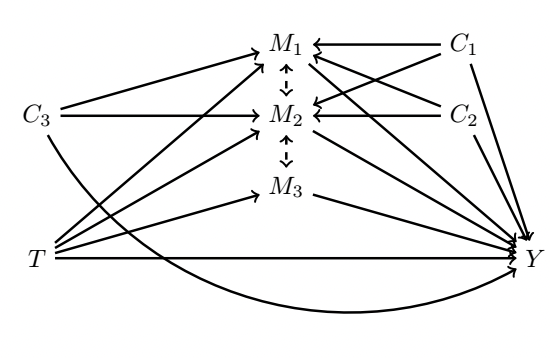

- Binary treatment $T$
- Linear Outcome $Y$
- Linear mediator $M_1$
- Binary mediator $,M_2$
- Polytomic mediator $M_3$
- Binary covariables $C_1,C_2,C_3$

```r
data(data4)
data4$Treatment=as.factor(data4$Treatment)
data4$C1=as.factor(data4$C1)
data4$C2=as.factor(data4$C2)
data4$C3=as.factor(data4$C3)
data4$M1=as.numeric(data4$M1)
data4$M3=as.factor(data4$M3)
data4$M2=as.factor(data4$M2)
data4$Outcome=as.numeric(data4$Outcome)
summary(data4)
```

```
#>  Treatment C1      C2      C3            M1         M2      M3
#>  0:530     0:501   0:399   0:605   Min.   : 7.944   0:841   0:533
#>  1:470     1:499   1:601   1:395   1st Qu.:16.721   1:159   1:224
#>                                    Median :21.915           2:243
#>                                    Mean   :21.988
#>                                    3rd Qu.:26.679
#>                                    Max.   :37.638
#>     Outcome
#>  Min.   : 38.22
#>  1st Qu.: 79.09
#>  Median :109.25
#>  Mean   :111.24
#>  3rd Qu.:140.45
#>  Max.   :194.37
```

```r
M1reg=lm(M1~  Treatment + C1 + C2 + C3, data = data4)
M2reg=glm(M2~ Treatment + C1 + C3, data = data4, family = binomial("probit"))
M3reg=polr(M3~Treatment + C2 + C3     , data = data4, method = "probit")
Yreg=lm(Outcome~ Treatment + M1 + M2 + M3 + C1 + C2 + C3, data=data4)
```

```r
med.analysis=multimediate(lmodel.m=list(M1reg,M2reg,M3reg),correlated=TRUE,model.y=Yreg,
                        treat="Treatment",treat.value=1,control.value=0,J=1000,conf.level=0.95)
```

[output not shown]

```r
summary(med.analysis,opt="avg")
```

```
#>               . Estimation  IC.inf  IC.sup P.val
#> 1    ACME.joint    47.9586 46.2903 49.5585 0.000
#> 2      PM.joint     0.8272  0.8061  0.8469 0.000
#> 3       ACME.M1    33.8316 33.0873 34.6129 0.000
#> 4         PM.M1     0.5837  0.5671  0.6016 0.000
#> 5       ACME.M2     0.0008 -0.0026  0.0056 0.644
#> 6         PM.M2     0.0000  0.0000  0.0001 0.644
#> 7       ACME.M3    14.1262 12.7203 15.5276 0.000
#> 8         PM.M3     0.2437  0.2183  0.2694 0.000
#> 9           ADE    10.0152  8.9144 11.1702 0.000
#> 10 Total Effect    57.9738 56.9722 58.9797 0.000
```

## Example 5

- Binary treatment $T$
- Survival Outcome $Y$
- Linear mediators $M_1,M_2,M_3$

```r
data(data5)
# data5$Exposure=as.factor(data5$Exposure)
# data5$M1=as.numeric(data5$M1)
# data5$M3=as.numeric(data5$M3)
# data5$M2=as.numeric(data5$M2)
# data5$Outcome=as.numeric(data5$Outcome)
summary(data5)
```

```
#>     Exposure            M1               M2               M3
#>  Min.   :0.0000   Min.   : 4.395   Min.   : 3.663   Min.   : 6.050
#>  1st Qu.:0.0000   1st Qu.: 7.332   1st Qu.: 6.623   1st Qu.: 9.563
#>  Median :1.0000   Median : 8.006   Median : 7.301   Median :10.269
#>  Mean   :0.5097   Mean   : 8.004   Mean   : 7.324   Mean   :10.292
#>  3rd Qu.:1.0000   3rd Qu.: 8.668   3rd Qu.: 8.031   3rd Qu.:11.011
#>  Max.   :1.0000   Max.   :11.361   Max.   :11.176   Max.   :13.883
#>      event     surv_time
#>  Min.   :1   Min.   :0.00000
#>  1st Qu.:1   1st Qu.:0.02000
#>  Median :1   Median :0.04000
#>  Mean   :1   Mean   :0.05808
#>  3rd Qu.:1   3rd Qu.:0.08000
#>  Max.   :1   Max.   :0.57000
```

```r
modM1=lm(M1 ~ Exposure, data = data5)
modM2=lm(M2 ~ Exposure, data = data5)
modM3=lm(M3 ~ Exposure, data = data5)
lmodel.m=list(modM1,modM2, modM3)

library(timereg)
model.y=aalen(Surv(surv_time, event) ~ const(Exposure) + const(M1) + const(M2) + const(M3), data = data5, robust=T)
```

```r
multi.media=multimediate(lmodel.m,correlated=TRUE,model.y,treat='Exposure',treat.value=1,control.value=0,J=1000,conf.level=0.95,data=data5)
```

```r
summary(multi.media, opt='avg')
```

```
#>               .  Estimation      IC.inf      IC.sup P.val
#> 1    ACME.joint 113526.7278  66341.5781 163930.8039 0.000
#> 2      PM.joint      0.5494      0.2540      1.1237 0.000
#> 3       ACME.M1   2103.6958  -4308.7569   9567.5636 0.514
#> 4         PM.M1      0.0104     -0.0210      0.0510 0.514
#> 5       ACME.M2  48168.9636  -1098.7624  94776.2611 0.056
#> 6         PM.M2      0.2322     -0.0043      0.5559 0.056
#> 7       ACME.M3  63254.0684  23719.4878 103248.6928 0.000
#> 8         PM.M3      0.3047      0.0965      0.6380 0.000
#> 9           ADE 112991.2513 -13482.2225 233612.2017 0.086
#> 10 Total Effect 226517.9791 112864.3347 342020.5498 0.000
```